# Statistics Report

### **Your Data**

This is the statistics report for the following: 2<sup>-(ΔCq)</sup>, samples: N_sample1, SC_sample1, and gene: IL6.

### **Sample Size Table**

| Sample | N |
| --- | --- |
| N_sample1 | 3 |
| SC_sample1 | 4 |

### **Normality Tests**

#### **Shapiro-Wilk Test**

Group

W

P_value

Passed_normality_test

P_value_summary

N_sample1

0.7565086

0.0144170

No

SC_sample1

0.9907428

0.9612426

Yes

ns

#### **QQ-Plot**

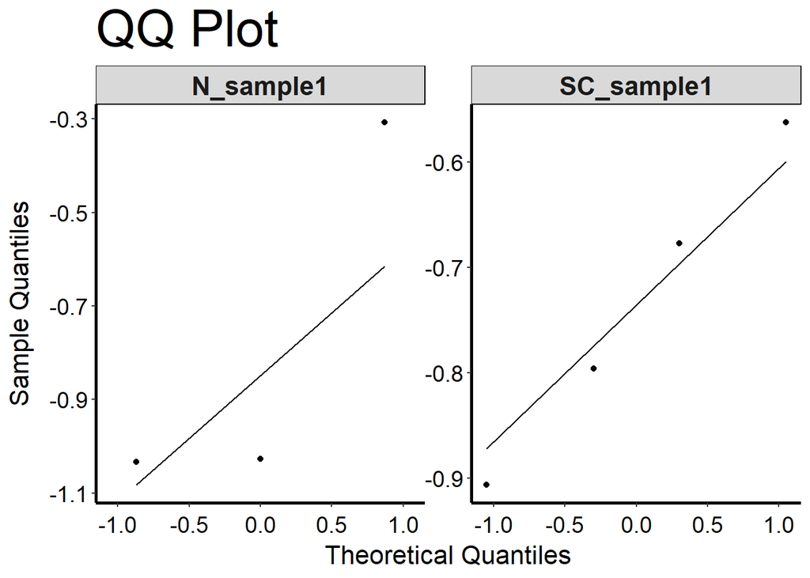

#### **Density Plot**

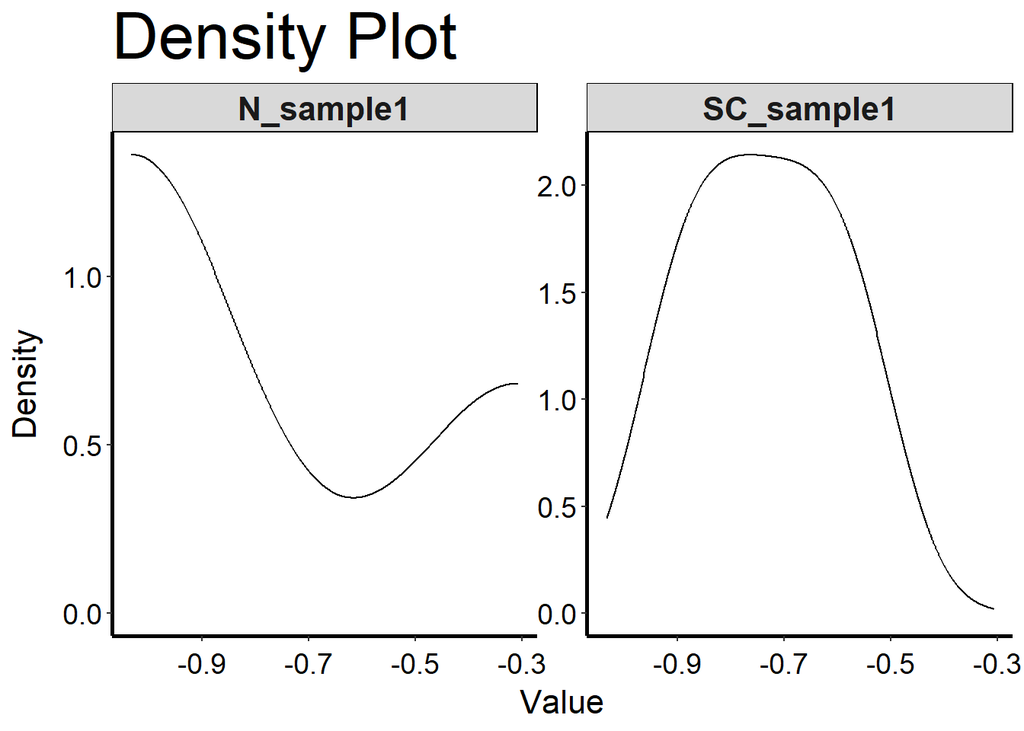

### **Homogeneity of Variance**

#### **Levene’s Test**

|  | df (Group) | df (Error) | F | P Value | Passed Variance Test? | P Value Summary |
| --- | --- | --- | --- | --- | --- | --- |
|  | 1 | 5 | 0.383985 | 0.5626214 | Yes | ns |

### **Log transformation?**

This data was log transformed.

### **Group Comparisons**

You selected a Independent T-Test test.

|  | group1 | group2 | t | df | P Value (Two-Tailed) | Significant? | P Value Summary |
| --- | --- | --- | --- | --- | --- | --- | --- |
|  | N_sample1 | SC_sample1 | 0.2431405 | 5 | 0.8175565 | No | ns |

### **Post-Hoc Tests**

Reminder, post-hoc tests are only valid if the group comparison test has a p value < 0.05. Not enough groups for post-hoc tests. Post-hoc test not selected.

#### **Compact Letter Notation**

Groups with the same letter are not significantly different from each other.

| Group | Letters |
| --- | --- |
| N_sample1 | a |
| SC_sample1 | a |

### **Contact**

If you have found any issues with this report, or want to suggest improvements, please contact the developer Marnie or email. Issues, or requests for features can also be added in the `Issues` tab on [GitHub](https://github.com/MarnieMaddock/FASTqPCR/issues). Note Colour Scheme suggestions for graphs can also be sent to Marnie.

[figure not shown]